# Lab3

Vedenichev Dmitry

29 12 2021

```r
knitr::opts_chunk$set(echo = TRUE)
```

# Задание:

1. 6. Файл ExpImp.RData. Приведите данные к формату tidydata. Отобразите значения суммарного экспорта и импорта по регионам в виде столбчатой диаграммы [сгруппировав значения по названию региона]. Экспорт и импорт обозначьте разными цветами. Сделайте второй график, на котором значения экспорта и импорта расположите по разные стороны относительно оси x. Подпишите величины экспорта и импорта.
2. 11. На портале открытых данных Тульской области есть данные о распределении площади лесов и запасов древесины по преобладающим породам и возраста https://opendata71.ru/opendata/7107096442-stateforestregisterTularegion/table. Скачайте эти данные в виде таблицы CSV и постройте по ним круговую и столбчатую диаграмму для категории Площадь земель, занятых лесными насаждениями (покрытых лесной растительностью), всего. Подберите цвета, попробуйте изменить ориентировку столбцов на горизонтальную, а для круговой диаграммы поменяейте угол поворота. Подпишите значения.

## Задание 1:

Загрузим начальные данные. Избавимс от мусора в столбцах. Просуммируем значения в столбцах с словами “Импорт” и “Экспорт”. Добавим их в исходные данные

```r
library(tidyverse)
library(ggplot2)
library(reshape2)

load("ExpImp.RData")
data <- as_tibble(ExpImp)
data <- data  %>% mutate_all(funs(gsub("-", "0", .)))
data <- data  %>% mutate_all(coalesce, "0")
data[,2:13] <- sapply(data[,2:13], as.double)
export <- data %>% select(contains('Экспорт')) %>% # 'select' function to choose the columns you want
    mutate(row_sum = rowSums(.)) # 'mutate' function to create
import <- data %>% select(contains('Импорт')) %>% # 'select' function to choose the columns you want
    mutate(row_sum = rowSums(.)) # 'mutate' function to create

data$export <- export$row_sum
data$import <- import$row_sum
data <- data %>% rename(region = 'Регион' )
print(data)
```

```
## # A tibble: 96 x 15
##    region       ПродЭкспорт ПродИмпорт ТЭКЭкспорт ТЭКИмпорт ХимЭкспорт ХимИмпорт
##    <chr>              <dbl>      <dbl>      <dbl>     <dbl>      <dbl>     <dbl>
##  1 Российская ~     16196.     43076.    371792.     3614.     30739.    50130.
##  2 Центральный~      4553.     22954.    204332.     1660.      8443.    34870.
##  3 Белгородска~       222.       614.        64.7      24.1       33.3     243.
##  4 Брянская об~        28.5      650.         5        20.5       24.5      71.7
##  5 Владимирска~       178.       454.         0.9      16.7       87.7     419
##  6 Воронежская~       374.       182.        38.9      38        977.       84.9
##  7 Ивановская ~         3.1      106.         0.1       0.1       40.8      57.4
##  8 Калужская о~        20.9      185.        14        57.9       54.9     370.
##  9 Костромская~         0.7        6.8        0         0         19.3      10.2
## 10 Курская обл~       140.       219.         0        17.7       77.2     118.
## # ... with 86 more rows, and 8 more variables: ДревЭкспорт <dbl>,
## #   ДревИмпорт <dbl>, МетЭкспорт <dbl>, МетИмпорт <dbl>, МашЭкспорт <dbl>,
## #   МашИмпорт <dbl>, export <dbl>, import <dbl>
```

Возьмем часть данных, преобразуем их и построим преобразованный датафрейм в график

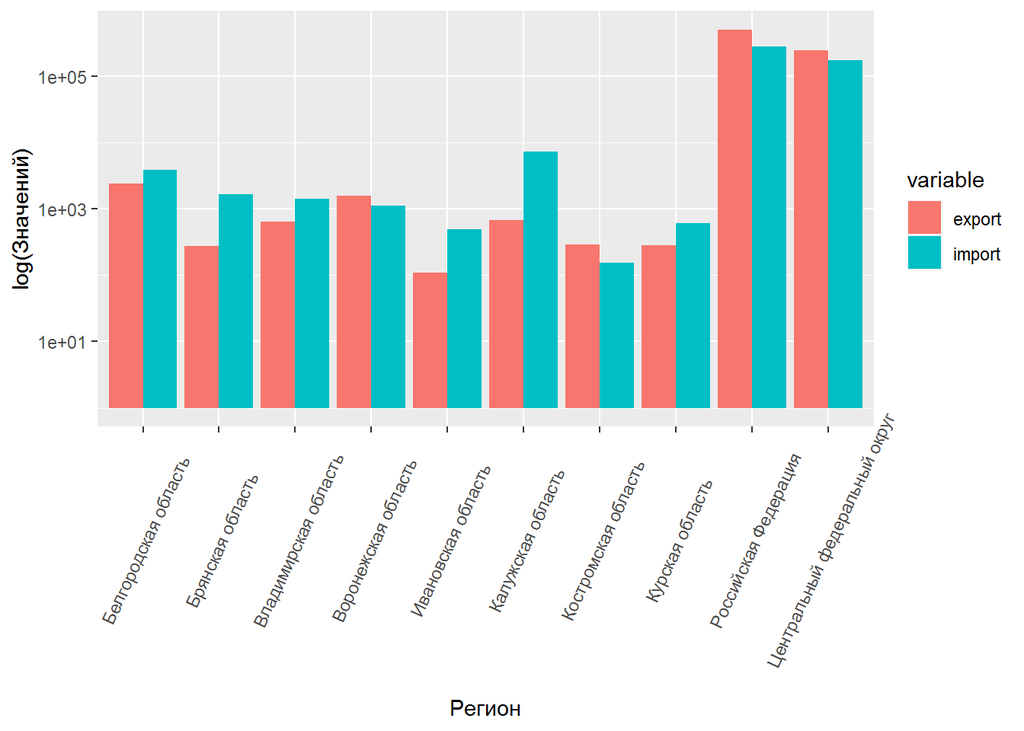

```r
semi_data <-data[1:10,]
dfm <- melt(semi_data[,c("region",'export','import')], id.vars = 1)
#
ggplot(dfm, aes(x = region, y = value)) +
    geom_bar(aes(fill = variable), stat = "identity", position = "dodge")+
  theme(axis.text.x = element_text(angle=65, vjust=0.6))+
  scale_y_log10()+xlab("Регион")+ylab("log(Значений)")
```

Возьмем чуток другие данные, без РФ, т.к. тут будем использовать отрицательные значения и логарифм плохо себя ведет. Считаем, что у экспорта отрицательные значения и строим график. Подписываем значения у столбцов

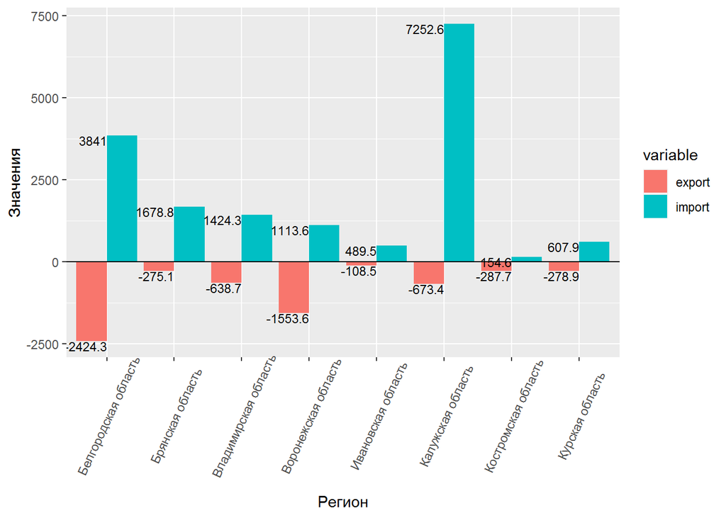

```r
semi_data <-data[3:10,]
semi_data$export <- -1 * semi_data$export
dfm <- melt(semi_data[,c("region",'export','import')], id.vars = 1)
ggplot(dfm, aes(x = region, y = value)) +
    geom_bar(aes(fill = variable), stat = "identity", position = "dodge")+
  theme(axis.text.x = element_text(angle=65, vjust=0.6))+
  xlab("Регион")+ylab("Значения")+
  geom_hline(aes(yintercept = 0))+
  geom_text(aes(label=value), vjust=1,hjust=1, color="black", size=3)
```

## Задание 2:

Отфильтруем изначальные данные. Поменяем кодировку файла на ANSI, поскольку UTF-8 неправильно читалось. Чтобы иметь возможность использовать фильтрм поменяем столбец, по которому фильтруем обратно к utf-8

```r
library(tidyverse)
file <- "data-forest.csv"
data <- as_tibble(read.csv(file,sep=";"))
data$naimenovanie_pokazatelya <- enc2utf8(data$naimenovanie_pokazatelya)
line  <-  as_tibble("Площадь земель, занятых лесными насаждениями (покрытых лесной растительностью), всего")
res <- filter(data, naimenovanie_pokazatelya %in% line)
res$znachenie_pokazatelya <- gsub(",", ".", res$znachenie_pokazatelya)
res$znachenie_pokazatelya <- as.numeric(res$znachenie_pokazatelya)

print(res)
```

```
## # A tibble: 14 x 4
##    preobladayushchie_d~ naimenovanie_pokazate~ edinitsa_izmere~ znachenie_pokaz~
##    <chr>                <chr>                  <chr>                       <dbl>
##  1 Cocнa                Площадь земель, занят~ тыс. га                      11.6
##  2 Eль                  Площадь земель, занят~ тыс. га                      11.8
##  3 Лиcтвeнницa          Площадь земель, занят~ тыс. га                       1.6
##  4 Дуб выcoкocтвoльный  Площадь земель, занят~ тыс. га                      47.9
##  5 Дуб низкocтвoльный   Площадь земель, занят~ тыс. га                      18.6
##  6 Яceнь                Площадь земель, занят~ тыс. га                       8.1
##  7 Клeн                 Площадь земель, занят~ тыс. га                       1.3
##  8 Вяз и другие         Площадь земель, занят~ тыс. га                       0.1
##  9 Бepeзa               Площадь земель, занят~ тыс. га                      87.4
## 10 Ocинa                Площадь земель, занят~ тыс. га                      43.5
## 11 Ольxa чepнaя         Площадь земель, занят~ тыс. га                       0.7
## 12 Липa                 Площадь земель, занят~ тыс. га                      33.7
## 13 Тoпoль               Площадь земель, занят~ тыс. га                       0.2
## 14 Ивы дpeвoвидныe      Площадь земель, занят~ тыс. га                       0.8
```

Построим графики:

### PIE CHART

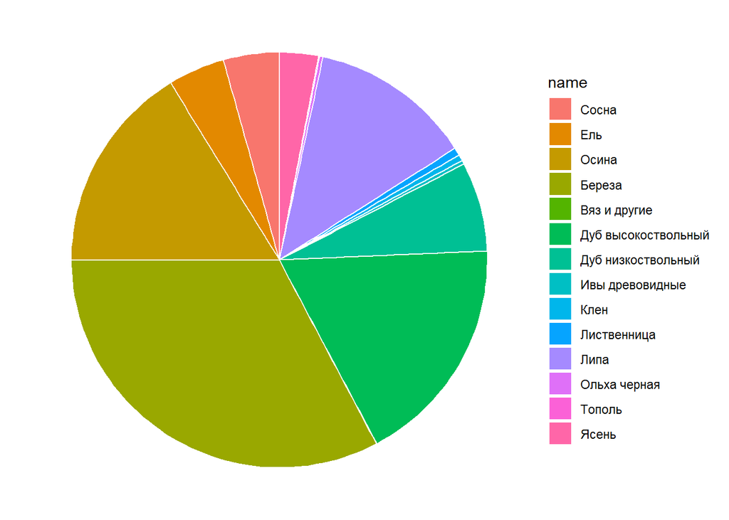

```r
library(ggplot2)

# Create Data
data <- data.frame(
  name=res$preobladayushchie_drevesnye_i_kustarnikovye_porody,
  value=res$znachenie_pokazatelya
)

ggplot(data, aes(x="", y=value, fill=name)) +
  geom_bar(stat="identity", width=1, color="white") +
  coord_polar("y", start=0) +

  theme_void() #
```

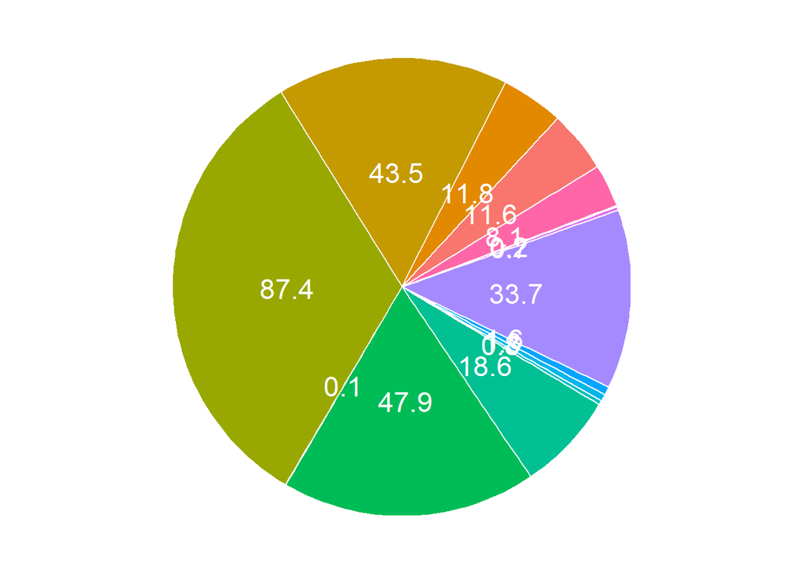

```r
semi_data <- data %>%
  arrange(desc(name)) %>%
  mutate(prop = value / sum(data$value) *100) %>%
  mutate(ypos = cumsum(prop)- 0.5*prop )

ggplot(semi_data, aes(x="", y=prop, fill=name)) +
  geom_bar(stat="identity", width=1, color="white") +
  coord_polar("y", start=45) +
  theme_void() +
  theme(legend.position="none") +

  geom_text(aes(y = ypos, label = value), color = "white", size=6)
```

### BAR CHART

Отрисуем Barchart

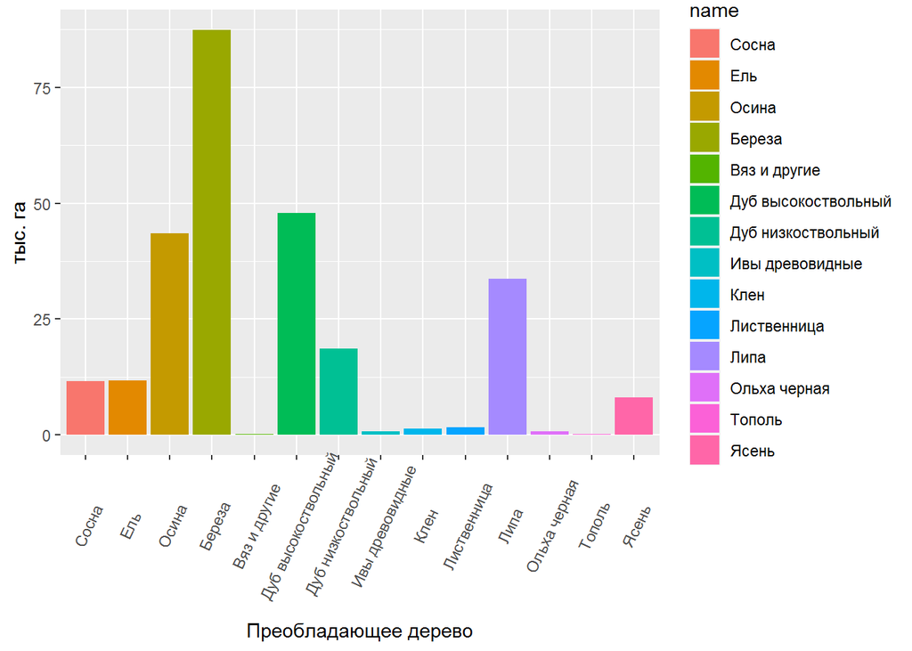

```r
p<-ggplot(data=data, aes(x=name, y=value, fill = name )) +
  geom_bar(stat="identity")+theme(axis.text.x = element_text(angle=65, vjust=0.6))+xlab("Преобладающее дерево")+ylab("тыс. га")
p
```

Повернем его

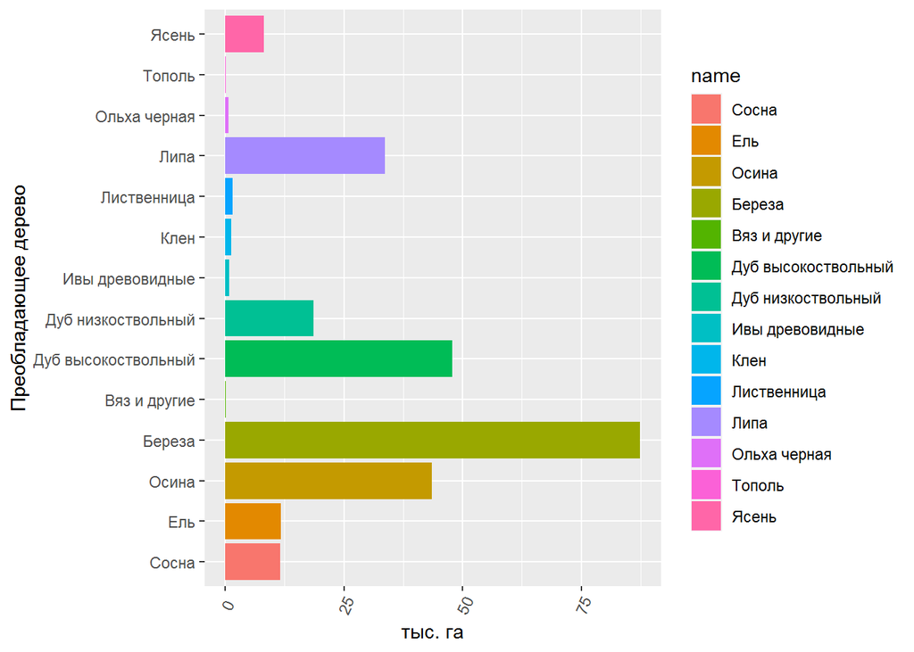

```r
p + coord_flip()
```

Поменяем цвета. Придется написать чуть сложный код, так как нет палетки длины 14. И добавим значения

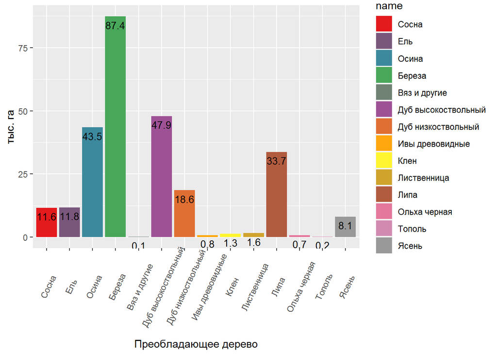

```r
library(RColorBrewer)
colourCount <- length(unique(data$name))
getPalette <- colorRampPalette(brewer.pal(9, "Set1"))
p+scale_fill_manual(values = getPalette(colourCount))+geom_text(aes(label=value), vjust=1.6, color="black", size=3.5)
```